# IS71068A Data Programming: Assignment 2

John Downing

```r
# load libraries
library(ggplot2)
library(colorspace)
library(gplots)
```

```r
# Helper functions

fillna <- function(col, replacement) {
  return (ifelse(is.na(col),replacement,col))
}

count <- function(x) {
  return (NROW(x))
}
```

## Part A

```r
# Set working directory to folder containing our csv file
setwd("C:/Users/john/dev/goldsmiths/data programming/assignment2")

# Load the csv file into a data frame. Note that we're explicitly
# specifying the data types for these, since CellID and countrycode
# are categorical - despite their numeric labels.
data <- read.csv(
  file = "sms-call-internet-mi-2013-11-01.csv",
  header = TRUE,
  colClasses = c("factor","factor","factor","double","double","double","double","double")
)
```

1. Write the R code to return the first 10 rows in the dataset.

```r
data[1:10,]
```

| datetime | CellID | countrycode | smsin | smsout | callin | callout | internet |
| --- | --- | --- | --- | --- | --- | --- | --- |
| 2013-11-01 00:00:00 | 1 | 0 | 0.3521 | NA | NA | 0.0273 | NA |
| 2013-11-01 00:00:00 | 1 | 33 | NA | NA | NA | NA | 0.0261 |
| 2013-11-01 00:00:00 | 1 | 39 | 1.7322 | 1.1047 | 0.5919 | 0.4020 | 57.7729 |
| 2013-11-01 00:00:00 | 2 | 0 | 0.3581 | NA | NA | 0.0273 | NA |
| 2013-11-01 00:00:00 | 2 | 33 | NA | NA | NA | NA | 0.0274 |
| 2013-11-01 00:00:00 | 2 | 39 | 1.7334 | 1.0880 | 0.6020 | 0.4109 | 57.8875 |
| 2013-11-01 00:00:00 | 3 | 0 | 0.3644 | NA | NA | 0.0273 | NA |
| 2013-11-01 00:00:00 | 3 | 33 | NA | NA | NA | NA | 0.0287 |
| 2013-11-01 00:00:00 | 3 | 39 | 1.7348 | 1.0701 | 0.6128 | 0.4203 | 58.0095 |
| 2013-11-01 00:00:00 | 4 | 0 | 0.3349 | NA | NA | 0.0273 | NA |

2. Write the R code to determine how many unique country codes are contained in the data.

```r
# Note I'm not including rows with countrycode == 0, as per the assignment
# instructions we can't assume very much about what they represent.
nonzerocc <- data$countrycode != 0
print(sprintf("Number of unique (not including zero) country codes: %s",
  length(unique(data[nonzerocc,]$countrycode))))
```

```
## [1] "Number of unique (not including zero) country codes: 245"
```

3. Plot the distribution of country codes in the data.

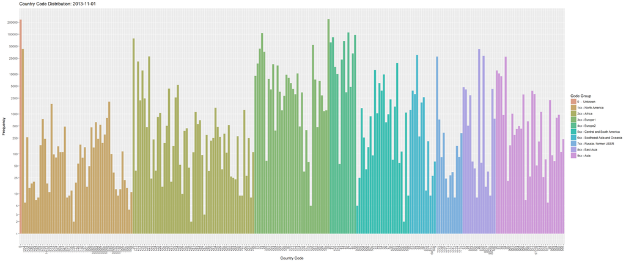

```r
# Note that this will be a barplot, not a histogram - since even though
# the labels for country codes are numeric, the data that they represent
# is not. It's not even ordinal - so we're not going to sort the x-axis
# numerically. There does appear to be *some* grouping structure, though
# - e.g. https://en.wikipedia.org/wiki/List_of_country_calling_codes. So
# on that basis, I'm going to use colour to visualise this per the legend
# below.
codegroup.labels <- c(
  "0  -  Unknown",
  "1xx - North America",
  "2xx - Africa",
  "3xx - Europe1",
  "4xx - Europe2",
  "5xx - Central and South America",
  "6xx - Southeast Asia and Oceania",
  "7xx - Russia / former USSR",
  "8xx - East Asia",
  "9xx - Asia"
)

# I'm adding a column to the data frame to identify which "code group"
# each row belongs to, by taking the first character of its countrycode.
data$codegroup <- apply(matrix(data$countrycode), 2,
  function (x) substr(x, 1, 1))

# These will be the y-axis labels/values - since otherwise (and because we're)
# using a log10 scale for the axis - the defaults aren't particularly helpful.
# There's probably something "clever" that could be done with combined sequences,
# rather than just hacking together a bunch of strings, but it didn't seem necessary.
yaxis.breaks <- c("1", "2", "3", "5", "10", "50", "25", "100", "250",
    "500", "1000", "2500", "5000", "10000", "25000", "50000", "100000", "200000")

# Am using ggplot2. Regards the x-axis labels, I've left them in (rotated by 90 degrees),
# since that seemed like the least bad option. To my way of thinking, it was either all or
# nothing; that is, there didn't seem to be a sensible way of including some of the
# labels but not others, in order to make them all fit onto a normally sized chart.
# (I did consider labelling only the ones with the highest frequencies from each group, but
# decided that this wouldn't add much value - nor would it be a very useful chart if I
# left all the labels off.) This version below only really works if you view it zoomed
# in - but then the nature of the data kind of demands that anyways.

print(
  ggplot(
    data = data,
    aes(
      x = countrycode,
      fill = codegroup
    )
  ) +
  geom_bar() +
  scale_fill_manual(
      name = "Code Group",
      values = rainbow_hcl(10, start=30, end=300),
      breaks = sort(unique(data$codegroup)),
      labels = codegroup.labels
  ) +
  scale_y_log10(
    breaks = as.integer(yaxis.breaks),
    labels = yaxis.breaks
  ) +
  theme(
    axis.text.x = element_text(angle=90, vjust=0.1, hjust=1)
  ) +
  ggtitle("Country Code Distribution: 2013-11-01") +
  labs(
    x = "Country Code",
    y = "Frequency"
  )
)
```

(Right click and save the above image in order to view at correct zoom level, for x-axis labels.)

4. Add a new column to your data called “totalsms”" that contains the sum of smsin and smsout. Similarly, add a new column to your data called “totalcalls” that contains the sum of callin and callout.

```r
# Note that we have to fill NAs with 0s, otherwise 0.3521 + NA (for example) = NA.
data$totalsms <- fillna(data$smsin, 0) + fillna(data$smsout, 0)
data$totalcalls <- fillna(data$callin, 0) + fillna(data$callout, 0)
data[1:10,]
```

| datetime | CellID | countrycode | smsin | smsout | callin | callout | internet | codegroup | totalsms | totalcalls |
| --- | --- | --- | --- | --- | --- | --- | --- | --- | --- | --- |
| 2013-11-01 00:00:00 | 1 | 0 | 0.3521 | NA | NA | 0.0273 | NA | 0 | 0.3521 | 0.0273 |
| 2013-11-01 00:00:00 | 1 | 33 | NA | NA | NA | NA | 0.0261 | 3 | 0.0000 | 0.0000 |
| 2013-11-01 00:00:00 | 1 | 39 | 1.7322 | 1.1047 | 0.5919 | 0.4020 | 57.7729 | 3 | 2.8369 | 0.9939 |
| 2013-11-01 00:00:00 | 2 | 0 | 0.3581 | NA | NA | 0.0273 | NA | 0 | 0.3581 | 0.0273 |
| 2013-11-01 00:00:00 | 2 | 33 | NA | NA | NA | NA | 0.0274 | 3 | 0.0000 | 0.0000 |
| 2013-11-01 00:00:00 | 2 | 39 | 1.7334 | 1.0880 | 0.6020 | 0.4109 | 57.8875 | 3 | 2.8214 | 1.0129 |
| 2013-11-01 00:00:00 | 3 | 0 | 0.3644 | NA | NA | 0.0273 | NA | 0 | 0.3644 | 0.0273 |
| 2013-11-01 00:00:00 | 3 | 33 | NA | NA | NA | NA | 0.0287 | 3 | 0.0000 | 0.0000 |
| 2013-11-01 00:00:00 | 3 | 39 | 1.7348 | 1.0701 | 0.6128 | 0.4203 | 58.0095 | 3 | 2.8049 | 1.0331 |
| 2013-11-01 00:00:00 | 4 | 0 | 0.3349 | NA | NA | 0.0273 | NA | 0 | 0.3349 | 0.0273 |

5. Plot the overall total of the “totalsms” column over the country code.

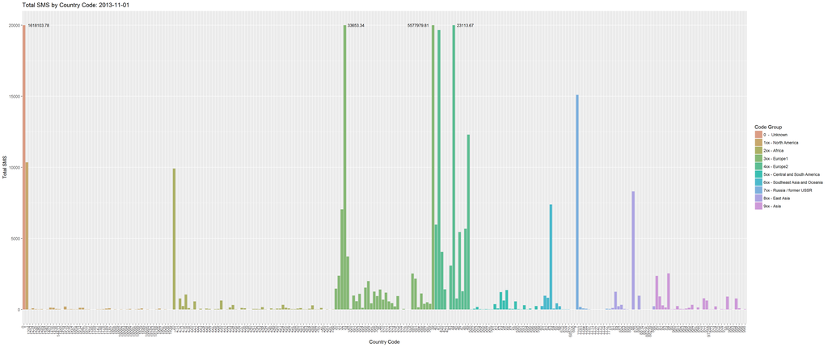

```r
# Slightly different logic for this one, regards the range on the y-axis.
# Again, a relatively small number of country codes have totalsms values
# which dwarf the majority - however we can't use a log scale, since some
# country codes have totalsms of zero, and log(0) is undefined. We could
# remove these country codes from the chart, but then we would lose that
# information (e.g. which country codes have zero totalsms). So instead,
# I'm using scales::squish to truncate anything above 20000, and manually
# annotating totalsms values for any countrycodes which exceed this.

# first do the "groupBy" with sum(x) as the aggregate function
smsByCountry <- aggregate(totalsms ~ countrycode, data, sum)
# add on our codegroup values, for visual fill colours
smsByCountry$codegroup <- apply(matrix(smsByCountry$countrycode), 2,
   function (x) substr(x, 1, 1))
# now do the (bar)plot
print(
  ggplot(
    data = smsByCountry,
    aes(
      x = countrycode,
      y = totalsms,
      fill = codegroup
    )
  ) +
  geom_bar(stat = "identity") +
  scale_fill_manual(
    name = "Code Group",
    values = rainbow_hcl(10, start=30, end=300),
    breaks = sort(unique(data$codegroup)),
    labels = codegroup.labels
  ) +
  scale_y_continuous(
    limits = c(0, 20000),
    oob = scales::squish
  ) +
  theme(
      axis.text.x = element_text(angle=90, vjust=0.1, hjust=1)
  ) +
  ggtitle("Total SMS by Country Code: 2013-11-01") +
  labs(
    x = "Country Code",
    y = "Total SMS"
  ) +
  annotate("text", x = 6, y = 22000, label = "1618103.78", size = 3) +
  annotate("text", x = 114, y = 22000, label = "33653.34 ", size = 3) +
  annotate("text", x = 135, y = 22000, label = "5577979.81", size = 3) +
  annotate("text", x = 151, y = 22000, label = "23113.67", size = 3)
)
```

(Right click and save the above image in order to view at correct zoom level, for x-axis labels.)

## PART B

6. Make a heatmap. The heat map should visualize the mean of the smsin, smsout, callin, callout, and internet data columns computed over the hour of the day.

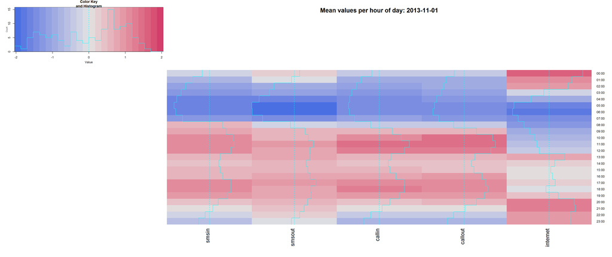

```r
# aggregate specified variables by hour of day, using "mean" as
# the aggregate function
mean.smsin <- aggregate(smsin ~ datetime, data, mean)
mean.smsout <- aggregate(smsout ~ datetime, data, mean)
mean.callin <- aggregate(callin ~ datetime, data, mean)
mean.callout <- aggregate(callout ~ datetime, data, mean)
mean.internet <- aggregate(internet ~ datetime, data, mean)

# create a dataframe for the (normalised) aggregate values..
hmap_data <- data.frame(
  datetime=mean.smsin$datetime,
  smsin=scale(mean.smsin$smsin),
  smsout=scale(mean.smsout$smsout),
  callin=scale(mean.callin$callin),
  callout=scale(mean.callout$callout),
  internet=scale(mean.internet$internet)
)
# ..and plot it (using gplots::heatmap.2, so we get a colour bar legend)
heatmap.2(
  data.matrix(hmap_data[,-1]),
  main = "Mean values per hour of day: 2013-11-01",
  labRow = apply(matrix(hmap_data$datetime), 2,
      function (x) substr(x, 11, 16)),
  Rowv = "none",
  Colv = "none",
  margins = c(8,5),
  dendrogram = "none",
  # blue = cold, red = hot etc
  col = diverge_hcl(24, c = 100, l = c(50, 90), power = 1)
)
```

## PART C

Run some analysis on the missing data

7. Which CellID has the most amount of missing data for the internet column?

```r
# apply logical filter so we only have rows where internet is NA
na.internet <- data[is.na(data$internet),]
# and now group these by CellID, using "count" as the aggregate function
na.internet <- aggregate(cbind(count = CellID) ~ CellID, na.internet, count)
# print off the row(s) which have the max NA count
max.na <- na.internet[na.internet$count == max(na.internet$count),]
print(sprintf("CellID with most (%s) NA values for variable 'internet': %s", max.na$count, max.na$CellID))
```

```
## [1] "CellID with most (541) NA values for variable 'internet': 6165"
```

8. Impute the internet data column by replacing the missing values with the mean of internet column.

```r
data$internet <- fillna(data$internet, mean(data$internet, na.rm=TRUE))
data[1:10,]
```

| datetime | CellID | countrycode | smsin | smsout | callin | callout | internet | codegroup | totalsms | totalcalls |
| --- | --- | --- | --- | --- | --- | --- | --- | --- | --- | --- |
| 2013-11-01 00:00:00 | 1 | 0 | 0.3521 | NA | NA | 0.0273 | 102.4773 | 0 | 0.3521 | 0.0273 |
| 2013-11-01 00:00:00 | 1 | 33 | NA | NA | NA | NA | 0.0261 | 3 | 0.0000 | 0.0000 |
| 2013-11-01 00:00:00 | 1 | 39 | 1.7322 | 1.1047 | 0.5919 | 0.4020 | 57.7729 | 3 | 2.8369 | 0.9939 |
| 2013-11-01 00:00:00 | 2 | 0 | 0.3581 | NA | NA | 0.0273 | 102.4773 | 0 | 0.3581 | 0.0273 |
| 2013-11-01 00:00:00 | 2 | 33 | NA | NA | NA | NA | 0.0274 | 3 | 0.0000 | 0.0000 |
| 2013-11-01 00:00:00 | 2 | 39 | 1.7334 | 1.0880 | 0.6020 | 0.4109 | 57.8875 | 3 | 2.8214 | 1.0129 |
| 2013-11-01 00:00:00 | 3 | 0 | 0.3644 | NA | NA | 0.0273 | 102.4773 | 0 | 0.3644 | 0.0273 |
| 2013-11-01 00:00:00 | 3 | 33 | NA | NA | NA | NA | 0.0287 | 3 | 0.0000 | 0.0000 |
| 2013-11-01 00:00:00 | 3 | 39 | 1.7348 | 1.0701 | 0.6128 | 0.4203 | 58.0095 | 3 | 2.8049 | 1.0331 |
| 2013-11-01 00:00:00 | 4 | 0 | 0.3349 | NA | NA | 0.0273 | 102.4773 | 0 | 0.3349 | 0.0273 |